# STATSII_project

Anup Bhutada, Ayush Pandey, Shouvik Sengupta, Uday Gadge

2023-05-01

## Predicting Green house emissions from Sensor data

Following is a data set collected from experiment set up to measure green house emissions from a turbine engine. There are different sensors set up to measure certain dependent features like temperature, pressure etc. The goal is to see to what extent these measurements can be useful to predict the emission of green house gases. There are two features here that measure these emissions `NOx` and `CO`.

**Reading the data**

The data is formatted year wise, so it needs to be merged.

```r
library(tidyr)
library(tidyverse)
```

```r
library(ggplot2)

path <- 'C:/Users/gadge/OneDrive/Desktop/STATS-II/Project/'
df1 <- read_csv(paste(path, 'gt_2011.csv', sep = '')) %>% mutate(year = 2011)
df2 <- read_csv(paste(path, 'gt_2012.csv', sep = '')) %>% mutate(year = 2012)
df3 <- read_csv(paste(path, 'gt_2013.csv', sep = '')) %>% mutate(year = 2013)
df4 <- read_csv(paste(path, 'gt_2014.csv', sep = '')) %>% mutate(year = 2014)
df5 <- read_csv(paste(path, 'gt_2015.csv', sep = '')) %>% mutate(year = 2014)
df <- rbind(df1, df2, df3, df4, df5)
head(df)
```

```
## # A tibble: 6 × 12
##      AT    AP    AH  AFDP  GTEP   TIT   TAT   TEY   CDP    CO   NOX  year
##   <dbl> <dbl> <dbl> <dbl> <dbl> <dbl> <dbl> <dbl> <dbl> <dbl> <dbl> <dbl>
## 1  4.59 1019.  83.7  3.58  24.0 1086.  550.  135.  11.9 0.327  82.0  2011
## 2  4.29 1018.  84.2  3.57  24.0 1086.  550.  135.  11.9 0.448  82.4  2011
## 3  3.90 1018.  84.9  3.58  24.0 1086.  550.  135.  12.0 0.451  83.8  2011
## 4  3.74 1018.  85.4  3.58  23.9 1086.  550.  135.  12.0 0.231  82.5  2011
## 5  3.75 1018.  85.2  3.58  23.9 1086.  550   135.  11.9 0.267  82.0  2011
## 6  3.89 1018.  83.9  3.58  23.9 1086   550.  135.  11.9 0.235  81.7  2011
```

```r
(colnames(df))
```

```
##  [1] "AT"   "AP"   "AH"   "AFDP" "GTEP" "TIT"  "TAT"  "TEY"  "CDP"  "CO"
## [11] "NOX"  "year"
```

```r
(dim(df))
```

```
## [1] 36733    12
```

** Data Exploration and Visualization **

The data has only numerical features.

```r
library(reshape2)
```

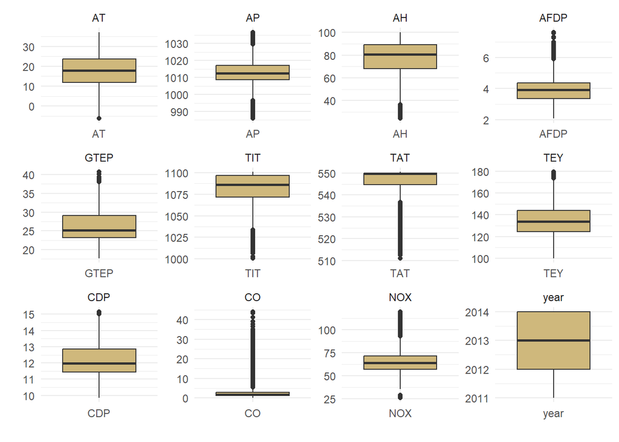

```r
p <- ggplot(melt(df), aes(factor(variable), value))
p + geom_boxplot(fill = "#CFB87C") + facet_wrap(~variable, scale="free")+xlab("")+ylab("")+
  theme_minimal()
```

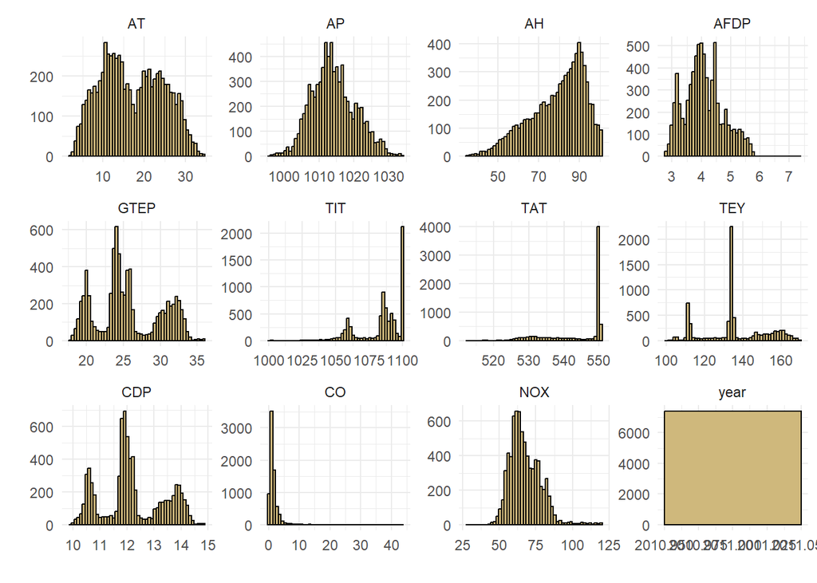

```r
library(reshape2)
p <- ggplot(melt(df1), aes(x=value))
p + geom_histogram(bins = 50, fill = "#CFB87C",col = "black") + facet_wrap(~variable, scale="free") + xlab("")+ylab("")+
  theme_minimal()
```

Exploring correlations between features

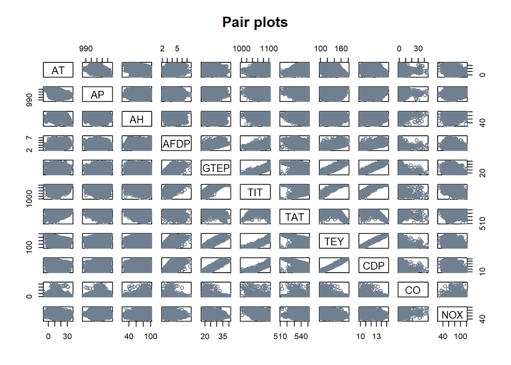

```r
pairs(df[,-12],col = "slategrey", main = "Pair plots")
```

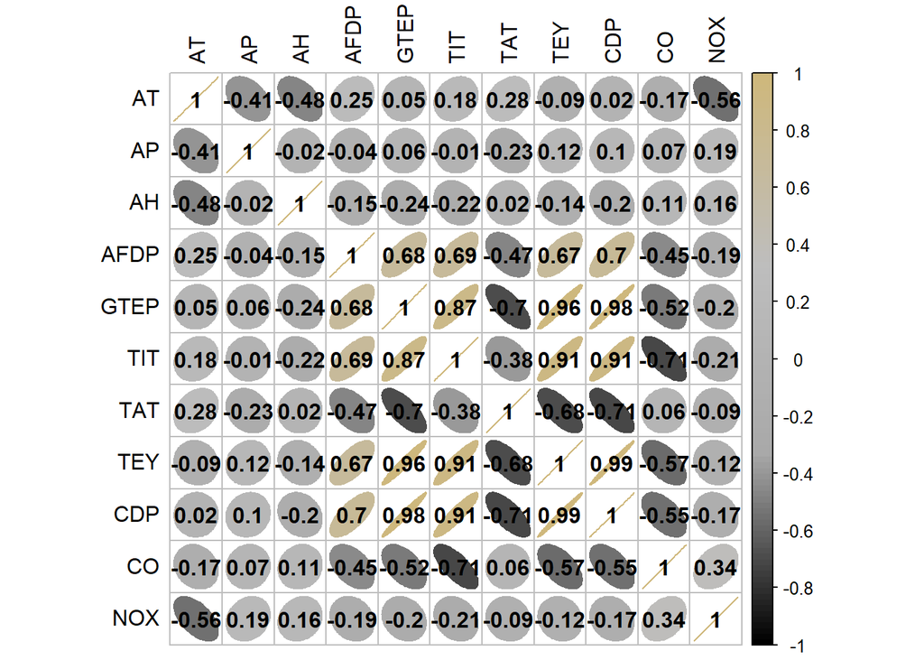

```r
library(corrplot)
col4 = colorRampPalette(c("black", "darkgrey", "grey","#CFB87C"))
corrplot(cor(df[,-12]), method = "ellipse", col = col4(100),  addCoef.col = "black", tl.col = "black")
```

There are some features with high correlation, looking at them closely.

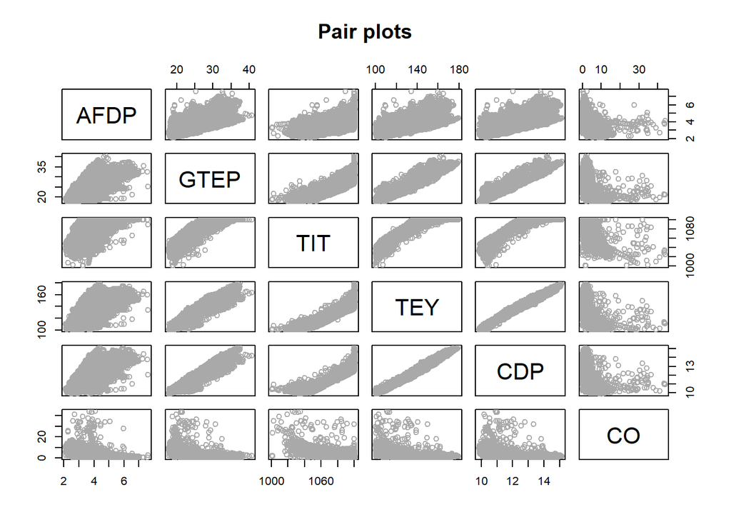

```r
pairs(df[c('AFDP', 'GTEP', 'TIT', 'TEY', 'CDP', 'CO')], col = "darkgrey",main = "Pair plots")
```

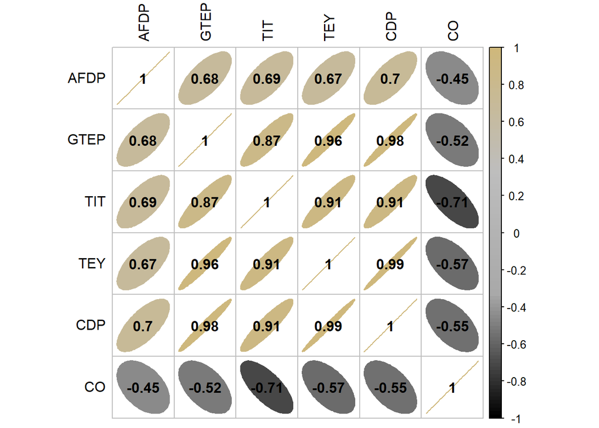

```r
library(corrplot)
col4 = colorRampPalette(c("black", "darkgrey", "grey","#CFB87C"))
corrplot(cor(df[c('AFDP', 'GTEP', 'TIT', 'TEY', 'CDP' , 'CO')]),
         method = "ellipse", col = col4(100),  addCoef.col = "black", tl.col = "black")
```

```r
lmod <- lm(CO ~ . - NOX - year - CDP, data = df)
summary(lmod)
```

```
##
## Call:
## lm(formula = CO ~ . - NOX - year - CDP, data = df)
##
## Residuals:
##     Min      1Q  Median      3Q     Max
## -11.924  -0.682  -0.093   0.532  34.798
##
## Coefficients:
##               Estimate Std. Error t value Pr(>|t|)
## (Intercept)  1.407e+02  2.105e+00  66.846  < 2e-16 ***
## AT          -1.566e-02  2.273e-03  -6.888 5.74e-12 ***
## AP           5.350e-03  1.394e-03   3.838 0.000124 ***
## AH          -7.472e-03  6.744e-04 -11.080  < 2e-16 ***
## AFDP        -1.249e-01  1.594e-02  -7.833 4.90e-15 ***
## GTEP         1.427e-01  9.847e-03  14.488  < 2e-16 ***
## TIT         -6.695e-02  2.758e-03 -24.271  < 2e-16 ***
## TAT         -1.146e-01  3.088e-03 -37.105  < 2e-16 ***
## TEY         -8.310e-02  4.902e-03 -16.954  < 2e-16 ***
## ---
## Signif. codes:  0 '***' 0.001 '**' 0.01 '*' 0.05 '.' 0.1 ' ' 1
##
## Residual standard error: 1.501 on 36724 degrees of freedom
## Multiple R-squared:  0.5599, Adjusted R-squared:  0.5598
## F-statistic:  5840 on 8 and 36724 DF,  p-value: < 2.2e-16
```

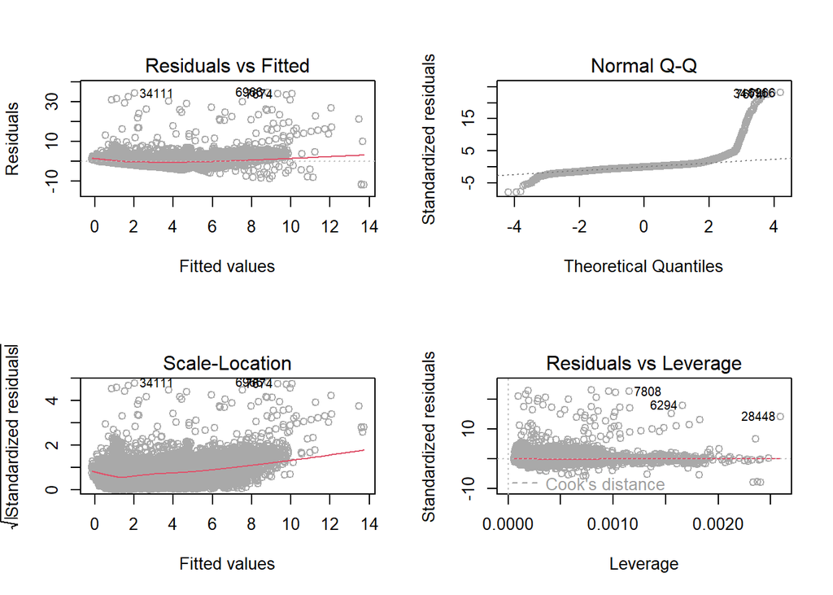

```r
par(mfrow = c(2,2))
plot(lmod,col = "darkgrey")
```

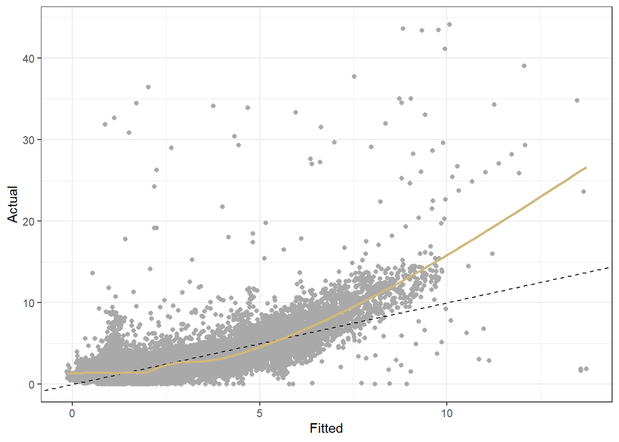

```r
ggplot(mapping = aes(fitted(lmod),df$CO)) + geom_point(col = "darkgrey")+
  geom_abline(slope = 1, intercept = 0, col = 'black',linetype = 'dashed')+
  geom_smooth(se = FALSE, col = "#CFB87C")+theme_bw()+xlab("Fitted") + ylab("Actual")
```

From the above plots, some key violations of linear regression are: - Linearity - Normality

They both look interlinked as from the histogram of `CO` it didn’t look normal. The fitted vs actual shows a parabolic curve.

The relation now looks like
$$y =
(\beta_0 + \beta_1x_1+...\beta_px_p)^2$$
A square root transformation would make this a linear. It might make it normal as well
$$\sqrt y = \beta_0 +
\beta_1x_1+...\beta_px_p$$

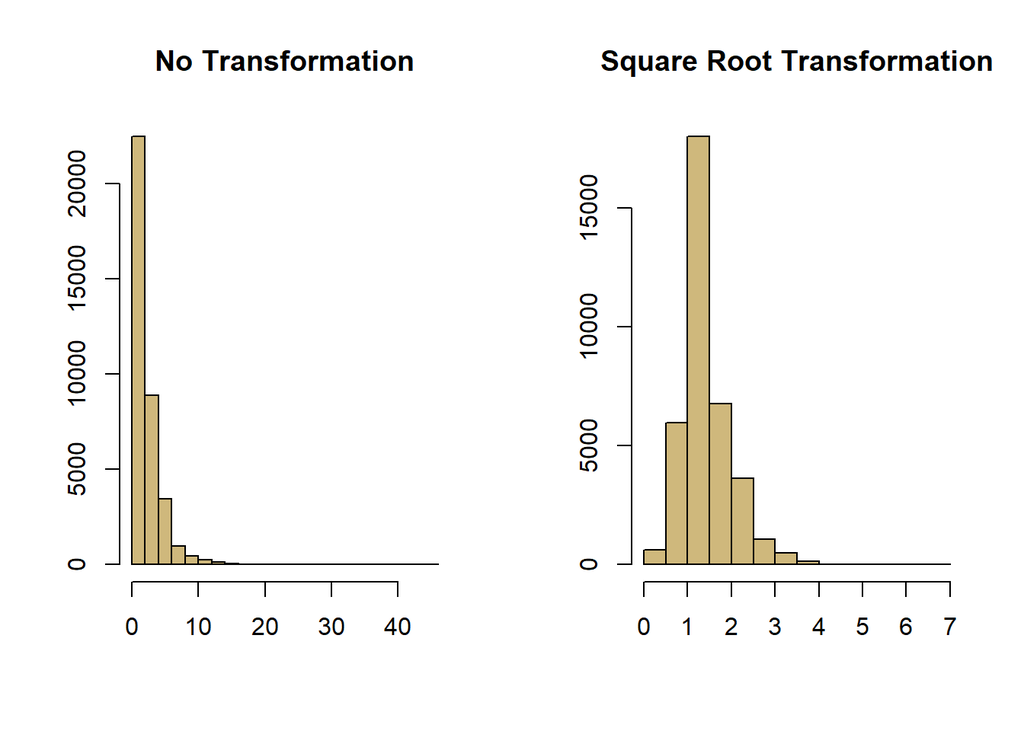

```r
par(mfrow = c(1,2))
hist(df$CO,col = "#CFB87C",main = "No Transformation",xlab = "",ylab = "")
hist(sqrt(df$CO),col = "#CFB87C",main = "Square Root Transformation",xlab = "",ylab = "")
```

** Transformation **

The transformation helped with normality to an extent as well. Fitting the model with transformation.

```r
lm_transform = lm(sqrt(CO) ~ . - year - NOX - CDP, data = df)
summary(lm_transform)
```

```
##
## Call:
## lm(formula = sqrt(CO) ~ . - year - NOX - CDP, data = df)
##
## Residuals:
##     Min      1Q  Median      3Q     Max
## -2.9499 -0.1922 -0.0025  0.1876  4.6593
##
## Coefficients:
##               Estimate Std. Error t value Pr(>|t|)
## (Intercept) 31.4015714  0.4944120  63.513  < 2e-16 ***
## AT          -0.0048910  0.0005339  -9.161  < 2e-16 ***
## AP           0.0024181  0.0003274   7.385 1.56e-13 ***
## AH          -0.0021218  0.0001584 -13.397  < 2e-16 ***
## AFDP        -0.0332135  0.0037446  -8.870  < 2e-16 ***
## GTEP         0.0510619  0.0023128  22.078  < 2e-16 ***
## TIT         -0.0221600  0.0006478 -34.208  < 2e-16 ***
## TAT         -0.0127783  0.0007252 -17.621  < 2e-16 ***
## TEY         -0.0179855  0.0011512 -15.623  < 2e-16 ***
## ---
## Signif. codes:  0 '***' 0.001 '**' 0.01 '*' 0.05 '.' 0.1 ' ' 1
##
## Residual standard error: 0.3526 on 36724 degrees of freedom
## Multiple R-squared:  0.6215, Adjusted R-squared:  0.6215
## F-statistic:  7539 on 8 and 36724 DF,  p-value: < 2.2e-16
```

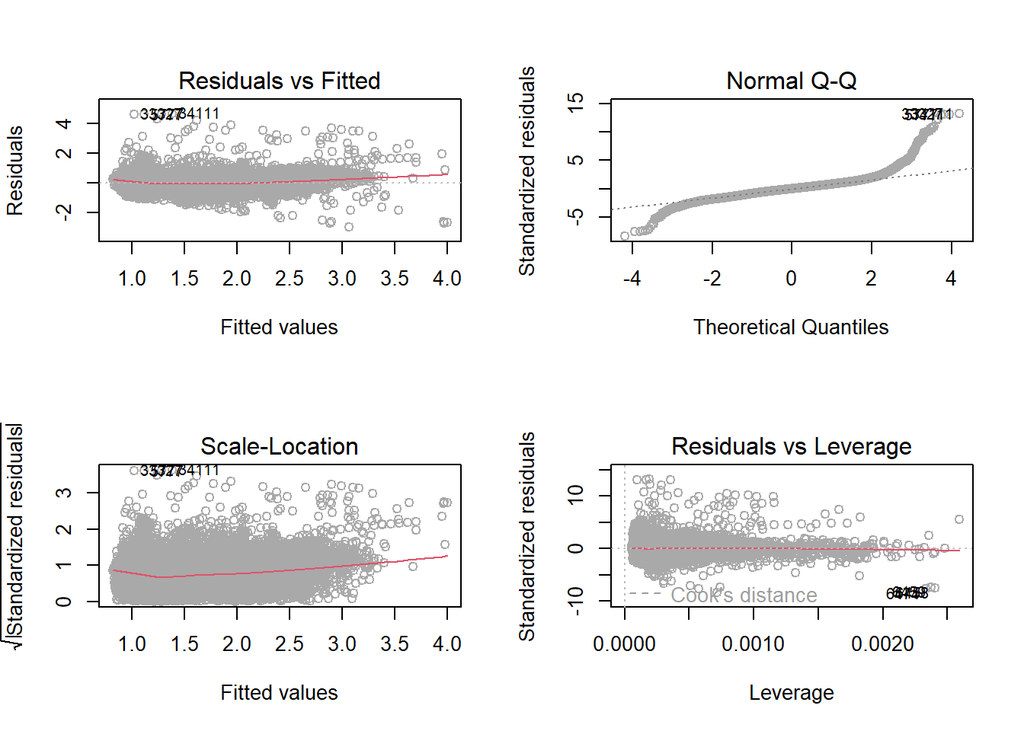

```r
par(mfrow = c(2,2))
plot(lm_transform, col = "darkgrey")
```

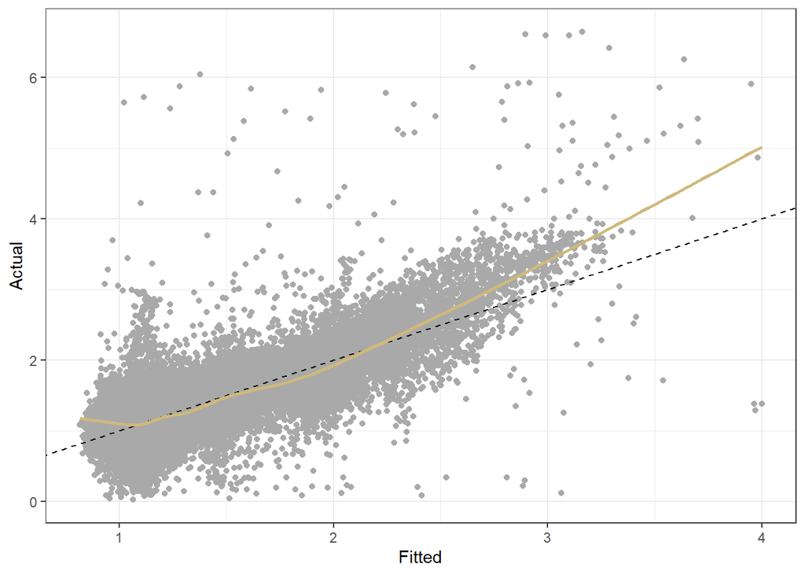

```r
ggplot(mapping = aes(fitted(lm_transform),sqrt(df$CO))) + geom_point(col = "darkgrey")+
  geom_abline(slope = 1, intercept = 0, col = 'black',linetype = 'dashed')+
  geom_smooth(se = FALSE, col = "#CFB87C")+theme_bw()+xlab("Fitted") + ylab("Actual")
```

Nomrality is still an issue.

Homoscedasticity looks violated to an extent. A weighted Least squares can be done to check for this.

The only measure that can be used to compare the pre transformed model and post transformed model is $R^2$ and $R_a^2$. `AIC` and `BIC` use `RSS` which changes as the response is scaled differently. The $R^2$ improved quite significantly with the transformation.

** Weighted Least Squares **

Looking at `CO` against all other features to decide the feature that can give an estimate on variance in `CO`

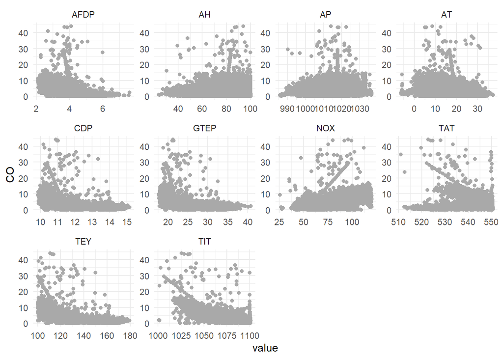

```r
df.gathered <- df[,-12] %>% gather(key = "variable", value = "value",-CO)
df.gathered %>% ggplot(aes(y = CO,x = value)) + geom_point(col = 'darkgrey')+
  facet_wrap(~variable,scales = 'free')+theme_minimal()
```

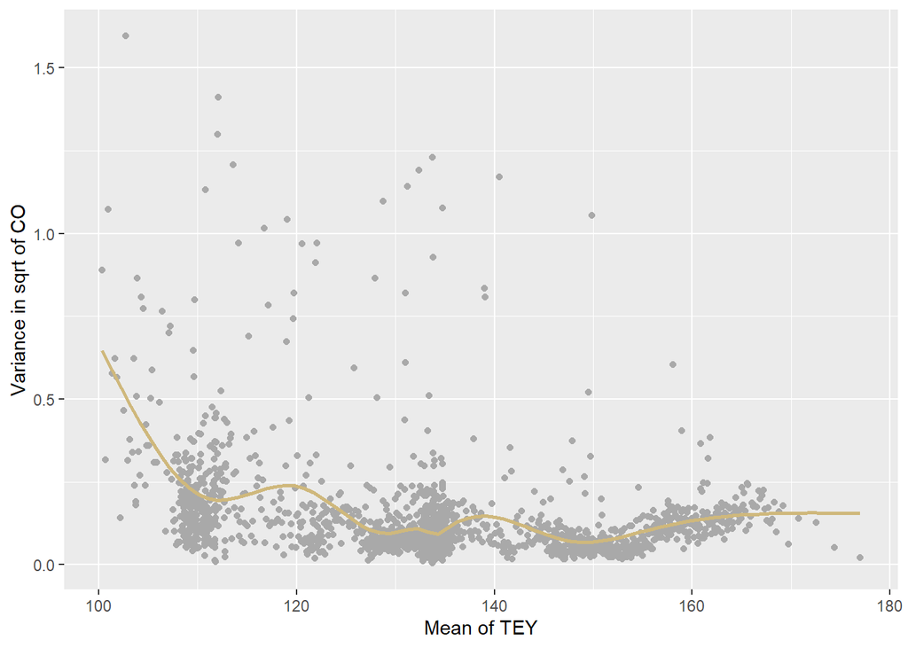

```r
i = order(df$TEY)
ndf = df[i,]

ff = head(gl(1837,20), 36733)

meanTEY = unlist(lapply(split(ndf$TEY,ff),mean))

varCO = unlist(lapply(split(sqrt(ndf$CO),ff),var));

ggplot(mapping = aes(x = meanTEY, y = varCO)) + geom_point(col = 'darkgrey') +
  geom_smooth(se = FALSE, col = "#CFB87C") + xlab("Mean of TEY") + ylab("Variance in sqrt of CO")
```

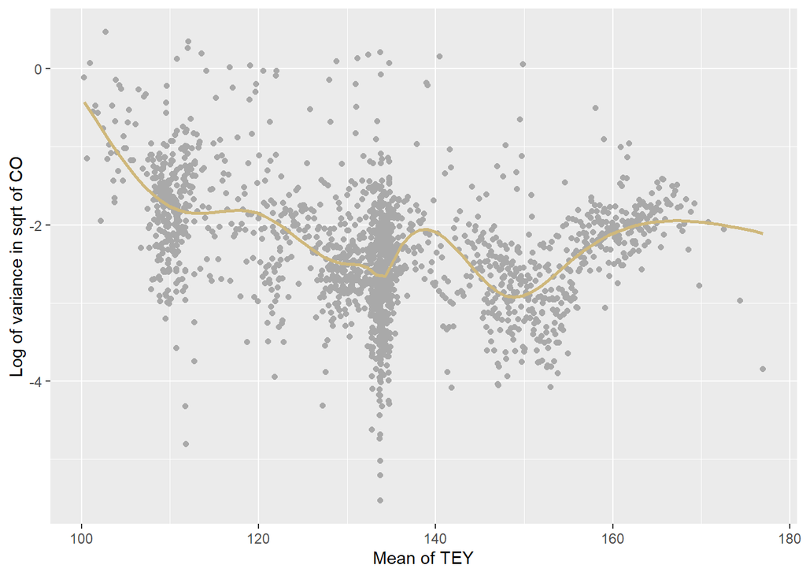

```r
ggplot(mapping = aes(x = meanTEY, y = log(varCO))) + geom_point(col = 'darkgrey') +
  geom_smooth(se = FALSE, col = "#CFB87C") + xlab("Mean of TEY") + ylab("Log of variance in sqrt of CO")
```

```r
lm_var = lm(log(varCO) ~ meanTEY)
summary(lm_var)
```

```
##
## Call:
## lm(formula = log(varCO) ~ meanTEY)
##
## Residuals:
##     Min      1Q  Median      3Q     Max
## -3.1966 -0.4869 -0.0123  0.4789  2.6174
##
## Coefficients:
##              Estimate Std. Error t value Pr(>|t|)
## (Intercept) -0.426852   0.149374  -2.858  0.00432 **
## meanTEY     -0.014260   0.001111 -12.833  < 2e-16 ***
## ---
## Signif. codes:  0 '***' 0.001 '**' 0.01 '*' 0.05 '.' 0.1 ' ' 1
##
## Residual standard error: 0.7443 on 1835 degrees of freedom
## Multiple R-squared:  0.08236,    Adjusted R-squared:  0.08186
## F-statistic: 164.7 on 1 and 1835 DF,  p-value: < 2.2e-16
```

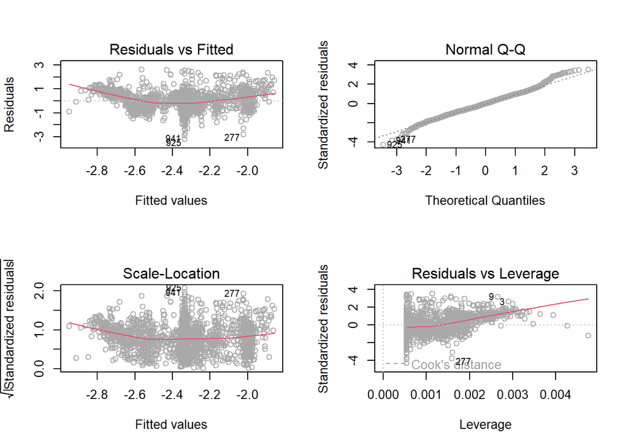

```r
par(mfrow = c(2,2))
plot(lm_var, col = 'darkgrey')
```

```r
var_resp <- exp(predict(lm_var, data.frame(meanTEY = df$TEY)))
length(var_resp)
```

```
## [1] 36733
```

```r
weights <- 1/var_resp
length(weights)
```

```
## [1] 36733
```

```r
lmodwls <- lm(sqrt(CO) ~ . - year - NOX - CDP, data = df, weights = weights)
summary(lmodwls)
```

```
##
## Call:
## lm(formula = sqrt(CO) ~ . - year - NOX - CDP, data = df, weights = weights)
##
## Weighted Residuals:
##     Min      1Q  Median      3Q     Max
## -7.6740 -0.6106 -0.0128  0.5943 16.4770
##
## Coefficients:
##               Estimate Std. Error t value Pr(>|t|)
## (Intercept) 29.4140478  0.4915630  59.838  < 2e-16 ***
## AT          -0.0026282  0.0005277  -4.981 6.37e-07 ***
## AP           0.0029679  0.0003218   9.223  < 2e-16 ***
## AH          -0.0024291  0.0001554 -15.635  < 2e-16 ***
## AFDP        -0.0409271  0.0035718 -11.458  < 2e-16 ***
## GTEP         0.0553637  0.0022628  24.467  < 2e-16 ***
## TIT         -0.0259769  0.0006416 -40.491  < 2e-16 ***
## TAT         -0.0041832  0.0007073  -5.914 3.36e-09 ***
## TEY         -0.0122333  0.0011289 -10.837  < 2e-16 ***
## ---
## Signif. codes:  0 '***' 0.001 '**' 0.01 '*' 0.05 '.' 0.1 ' ' 1
##
## Residual standard error: 1.126 on 36724 degrees of freedom
## Multiple R-squared:  0.5735, Adjusted R-squared:  0.5734
## F-statistic:  6172 on 8 and 36724 DF,  p-value: < 2.2e-16
```

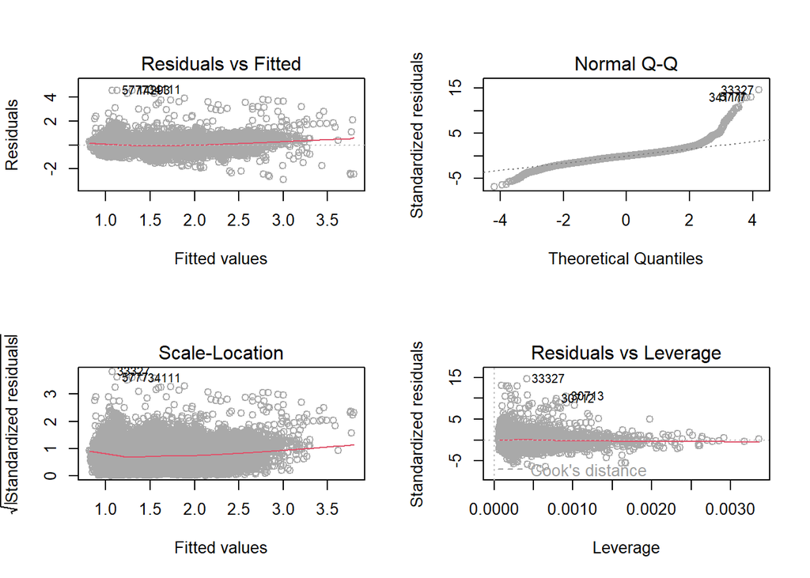

```r
par(mfrow = c(2,2))
plot(lmodwls, col = "darkgrey")
```

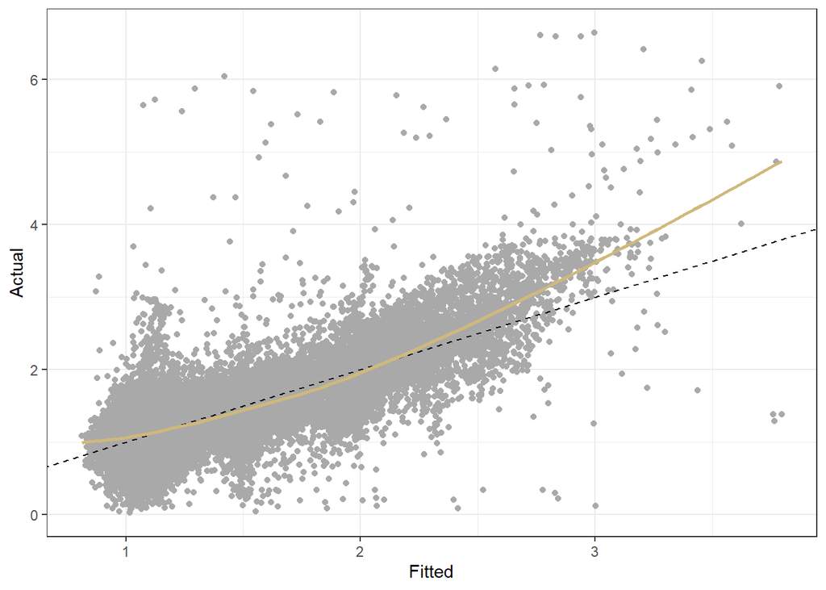

```r
ggplot(mapping = aes(fitted(lmodwls),sqrt(df$CO))) + geom_point(col = "darkgrey")+
  geom_abline(slope = 1, intercept = 0, col = 'black',linetype = 'dashed')+
  geom_smooth(se = FALSE, col = "#CFB87C")+theme_bw()+xlab("Fitted") + ylab("Actual")
```

```r
summary(weights)
```

```
##    Min. 1st Qu.  Median    Mean 3rd Qu.    Max.
##   6.380   9.039  10.317  10.545  11.958  19.817
```

The reason `WLS` didn’t work is the variance we tried estimated variance using `TEY` and that model has a very low $R^2$ indicating that the weights are not calculated properly.

** Multicolinearity check **

```r
library(car)
vif(lm_transform)
```

```
##        AT        AP        AH      AFDP      GTEP       TIT       TAT       TEY
##  4.671715  1.323365  1.550092  2.481707 27.826201 38.133407  7.275014 95.524902
```

There are features with high VIF.

```r
kappa(lm_transform)
```

```
## [1] 137094.9
```

The value of kappa is also too high. This is not a least variance model.

## Model selection

We can try to remove the predictor with highest VIF value, but this caused other predictors to become insignificant. Therefore we are using a systematic approach to remove multicollinearity.

```r
library(leaps)
library(MASS)
n = dim(df)[1];
reg1 = regsubsets(sqrt(CO) ~ . - year - NOX - CDP, data = df)
rs = summary(reg1)
rs$which
```

```
##   (Intercept)    AT    AP    AH  AFDP  GTEP  TIT   TAT   TEY
## 1        TRUE FALSE FALSE FALSE FALSE FALSE TRUE FALSE FALSE
## 2        TRUE FALSE FALSE FALSE FALSE  TRUE TRUE FALSE FALSE
## 3        TRUE FALSE FALSE  TRUE FALSE  TRUE TRUE FALSE FALSE
## 4        TRUE FALSE  TRUE  TRUE FALSE  TRUE TRUE FALSE FALSE
## 5        TRUE FALSE  TRUE  TRUE FALSE  TRUE TRUE  TRUE FALSE
## 6        TRUE  TRUE FALSE  TRUE FALSE  TRUE TRUE  TRUE  TRUE
## 7        TRUE  TRUE FALSE  TRUE  TRUE  TRUE TRUE  TRUE  TRUE
## 8        TRUE  TRUE  TRUE  TRUE  TRUE  TRUE TRUE  TRUE  TRUE
```

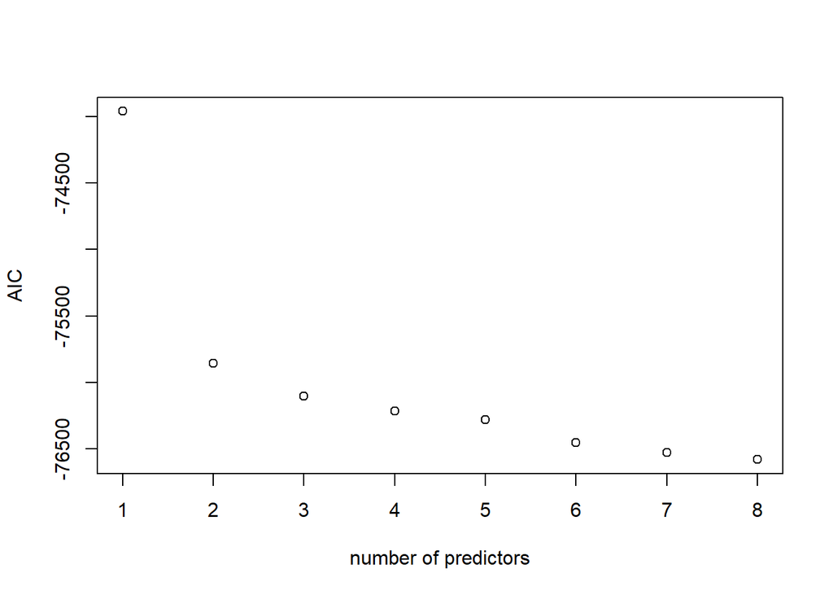

```r
AIC <- 2*(2:9) + n*log(rs$rss/n)
plot(AIC ~ I(1:8), xlab = "number of predictors", ylab = 'AIC')
```

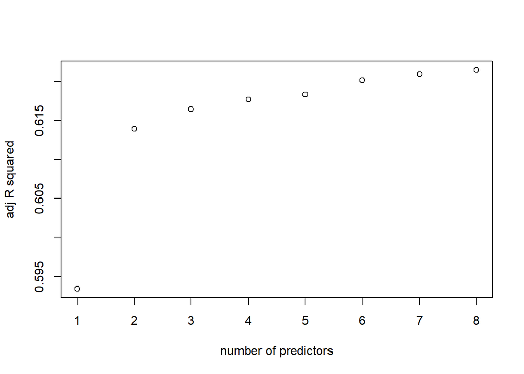

```r
plot(1:8, rs$adjr2, xlab = "number of predictors", ylab = "adj R squared")
```

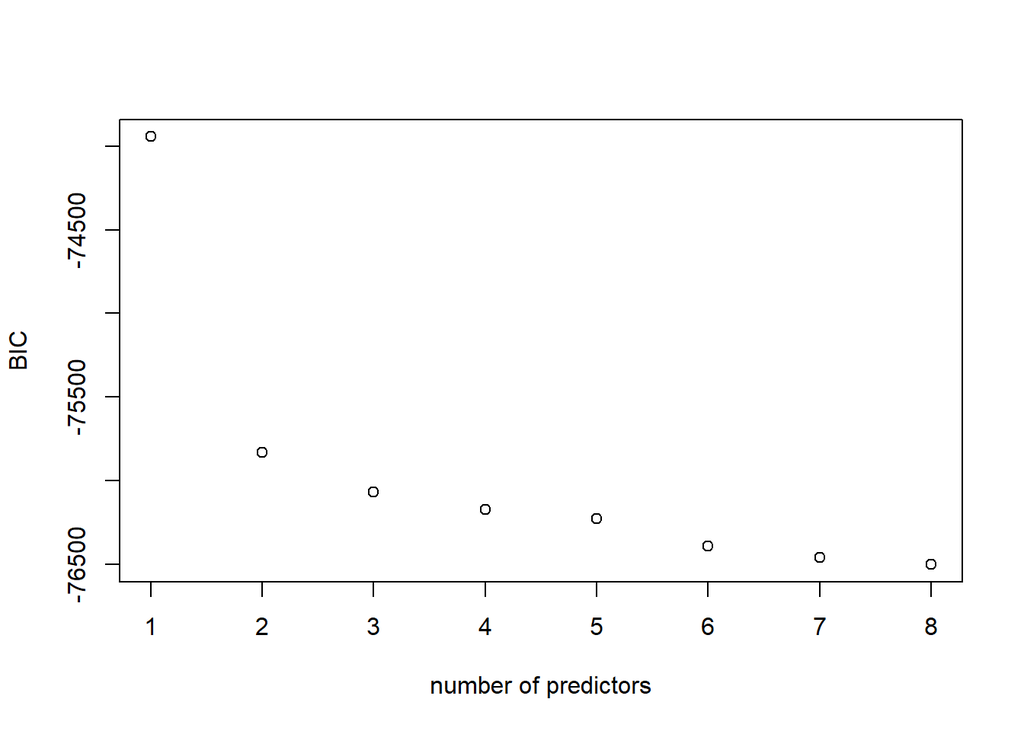

```r
BIC = log(n)*(2:9) + n*log(rs$rss/n)
plot(BIC ~ I(1:8), xlab = "number of predictors", ylab = "BIC")
```

```r
lm_6 <- lm(sqrt(CO) ~ . - year - NOX - CDP - AP - AFDP, data = df)
summary(lm_6)
```

```
##
## Call:
## lm(formula = sqrt(CO) ~ . - year - NOX - CDP - AP - AFDP, data = df)
##
## Residuals:
##     Min      1Q  Median      3Q     Max
## -2.9405 -0.1939 -0.0043  0.1876  4.6689
##
## Coefficients:
##               Estimate Std. Error t value Pr(>|t|)
## (Intercept) 34.0584117  0.3608745   94.38   <2e-16 ***
## AT          -0.0069302  0.0005010  -13.83   <2e-16 ***
## AH          -0.0026320  0.0001513  -17.40   <2e-16 ***
## GTEP         0.0501609  0.0023105   21.71   <2e-16 ***
## TIT         -0.0230291  0.0006284  -36.65   <2e-16 ***
## TAT         -0.0115799  0.0006839  -16.93   <2e-16 ***
## TEY         -0.0176361  0.0011495  -15.34   <2e-16 ***
## ---
## Signif. codes:  0 '***' 0.001 '**' 0.01 '*' 0.05 '.' 0.1 ' ' 1
##
## Residual standard error: 0.3532 on 36726 degrees of freedom
## Multiple R-squared:  0.6202, Adjusted R-squared:  0.6201
## F-statistic:  9994 on 6 and 36726 DF,  p-value: < 2.2e-16
```

```r
vif(lm_6)
```

```
##        AT        AH      GTEP       TIT       TAT       TEY
##  4.098392  1.409444 27.674546 35.754113  6.448129 94.912986
```

```r
kappa(lm_6)
```

```
## [1] 123964
```

Removal of further features would decrease the metrics, so regularization to see if we can get a model with lower variance.

** Regularization**

```r
df_norm <- df %>% mutate(CO_sqrt = sqrt(CO))
df_norm <- df_norm %>% dplyr::select(-c(CO))

df_norm <-  as.data.frame(scale(df_norm))

lm_norm <- lm(CO_sqrt ~ . - year - NOX - CDP, data = df_norm)
summary(lm_norm)
```

```
##
## Call:
## lm(formula = CO_sqrt ~ . - year - NOX - CDP, data = df_norm)
##
## Residuals:
##     Min      1Q  Median      3Q     Max
## -5.1477 -0.3354 -0.0044  0.3273  8.1307
##
## Coefficients:
##               Estimate Std. Error t value Pr(>|t|)
## (Intercept) -1.177e-15  3.210e-03   0.000        1
## AT          -6.356e-02  6.939e-03  -9.161  < 2e-16 ***
## AP           2.727e-02  3.693e-03   7.385 1.56e-13 ***
## AH          -5.354e-02  3.997e-03 -13.397  < 2e-16 ***
## AFDP        -4.486e-02  5.057e-03  -8.870  < 2e-16 ***
## GTEP         3.739e-01  1.693e-02  22.078  < 2e-16 ***
## TIT         -6.781e-01  1.982e-02 -34.208  < 2e-16 ***
## TAT         -1.526e-01  8.659e-03 -17.621  < 2e-16 ***
## TEY         -4.902e-01  3.138e-02 -15.623  < 2e-16 ***
## ---
## Signif. codes:  0 '***' 0.001 '**' 0.01 '*' 0.05 '.' 0.1 ' ' 1
##
## Residual standard error: 0.6153 on 36724 degrees of freedom
## Multiple R-squared:  0.6215, Adjusted R-squared:  0.6215
## F-statistic:  7539 on 8 and 36724 DF,  p-value: < 2.2e-16
```

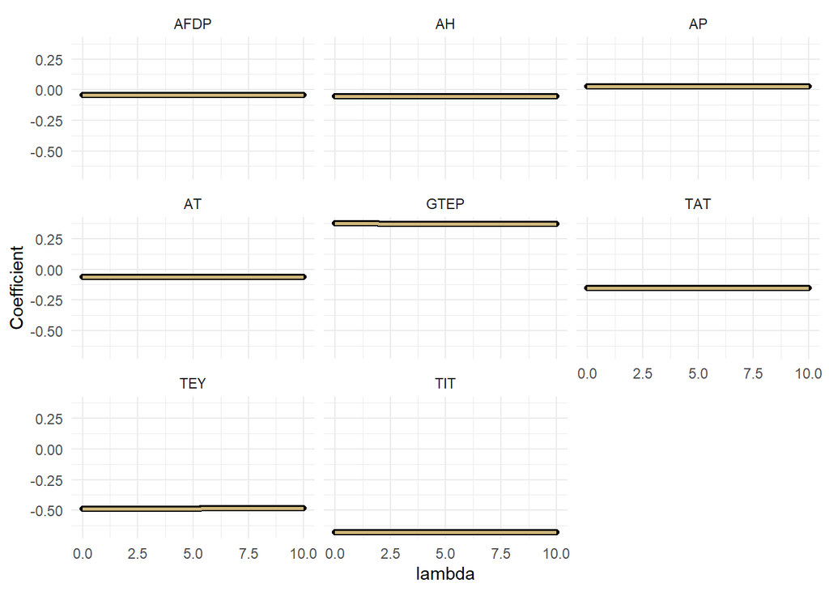

```r
lm_ridge <- lm.ridge(CO_sqrt ~ . - year - NOX - CDP - 1, data = df_norm, lambda = seq(0, 10, 0.01))
lm_ridge_df <- as.data.frame(t(lm_ridge$coef))
lm_ridge_df$lambda <- lm_ridge$lambda
lm_ridge_df <- lm_ridge_df%>% gather(key = "variable", value = "value", -lambda)
lm_ridge_df %>% ggplot(aes(lambda, value)) + geom_point() + geom_smooth(se = FALSE, col = "#CFB87C")+
  xlab('lambda') + ylab('Coefficient') + facet_wrap(~variable) + theme_minimal()
```

No smoothing is happening

```r
(mod <- select(lm_ridge))
```

```
## modified HKB estimator is 2.602046
## modified L-W estimator is 3.654323
## smallest value of GCV  at 3.8
```

```r
lm_ridge_l <- lm.ridge(CO_sqrt ~ . - year - NOX - CDP - 1, data = df_norm, lambda = 3.8)
```

```r
y.pred <- as.matrix(df_norm %>% dplyr::select(-c(CDP, NOX, year, CO_sqrt))) %*% coef(lm_ridge_l)
length(y.pred)
```

```
## [1] 36733
```

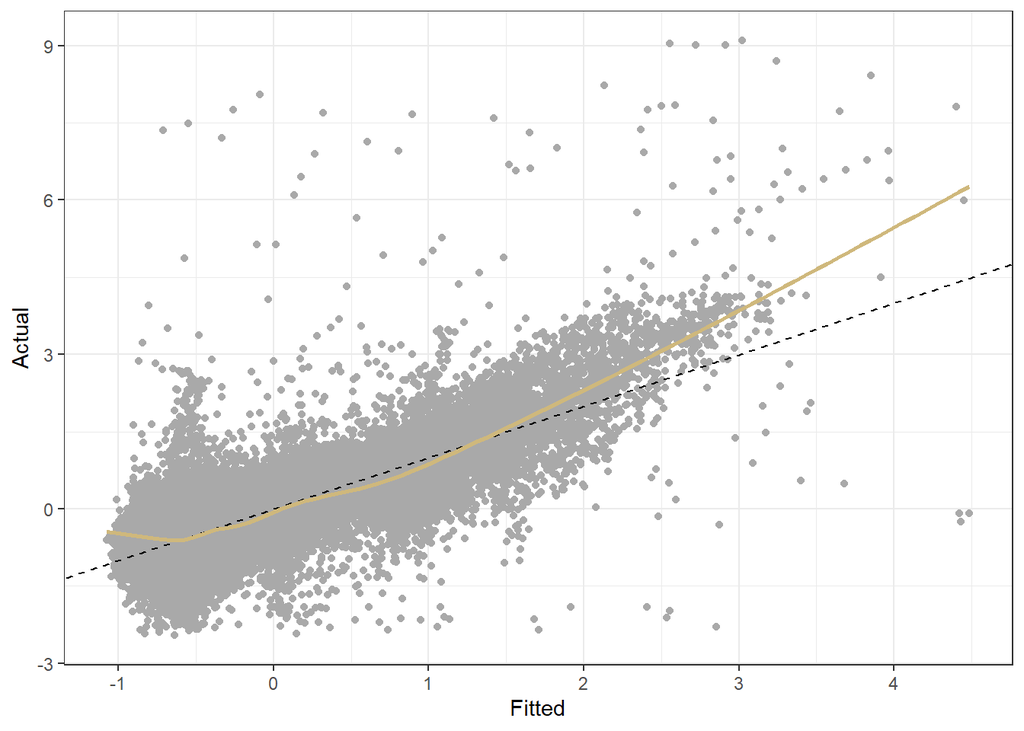

```r
ggplot(mapping = aes(x = y.pred, y = df_norm$CO_sqrt)) + geom_point(col = "darkgrey")+
  geom_abline(slope = 1, intercept = 0, col = 'black',linetype = 'dashed')+
  geom_smooth(se = FALSE, col = "#CFB87C")+theme_bw()+xlab("Fitted") + ylab("Actual")
```

The regularization isn’t affecting anything. We can test MSPE of this with the original model to see if it’s better.

** Correlated Errors**

```r
library(gridExtra)
```

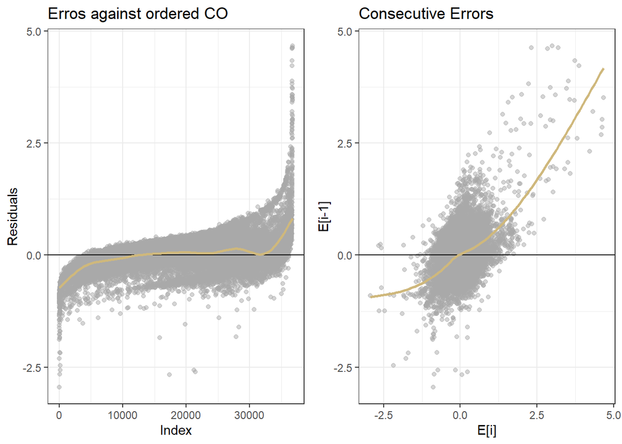

```r
ind <- order(df$CO)
p1 <- ggplot(mapping = aes(x = 1:length(df$CO), y = residuals(lm_6)[ind])) +
  geom_point(alpha = 0.5, col = 'darkgrey') +
  geom_abline(slope = 0, intercept = 0) +
  xlab("Index") +
  geom_smooth(se = F, col = "#CFB87C") +
  ylab("Residuals") +
  theme_bw()+ggtitle("Erros against ordered CO")

ordered.reiduals <- residuals(lm_6)[ind]
p2 <- ggplot(mapping = aes(x = ordered.reiduals[-length(ordered.reiduals)],
                           y = ordered.reiduals[-1]))+
               geom_point(alpha = 0.5, col = 'darkgrey') +
               geom_abline(slope = 0, intercept = 0) +
               xlab("E[i]") +
               geom_smooth(se = F, col = "#CFB87C") +
  ylab("E[i-1]") +
  theme_bw()+ggtitle("Consecutive Errors")

grid.arrange(p1,p2, nrow = 1)
```

```r
(cor.error <- cor(ordered.reiduals[-1],ordered.reiduals[-length(ordered.reiduals)]))
```

```
## [1] 0.4915668
```

There is some correlation in error terms.

** GLS **

```r
library(nlme)
df_ordered <- df[ind,]
df_ordered$index <- 1:length(ind)
gls.6 <- gls(sqrt(CO) ~ . - year - NOX - CDP - AP - AFDP - index, data = df_ordered, correlation = corAR1(form = ~ 1 | index))
summary(gls.6)
```

```
## Generalized least squares fit by REML
##   Model: sqrt(CO) ~ . - year - NOX - CDP - AP - AFDP - index
##   Data: df_ordered
##        AIC      BIC    logLik
##   27892.73 27969.33 -13937.37
##
## Correlation Structure: AR(1)
##  Formula: ~1 | index
##  Parameter estimate(s):
## Phi
##   0
##
## Coefficients:
##                Value Std.Error   t-value p-value
## (Intercept) 34.05841 0.3608745  94.37743       0
## AT          -0.00693 0.0005010 -13.83379       0
## AH          -0.00263 0.0001513 -17.39664       0
## GTEP         0.05016 0.0023105  21.70964       0
## TIT         -0.02303 0.0006284 -36.64799       0
## TAT         -0.01158 0.0006839 -16.93133       0
## TEY         -0.01764 0.0011495 -15.34193       0
##
##  Correlation:
##      (Intr) AT     AH     GTEP   TIT    TAT
## AT    0.708
## AH    0.004  0.281
## GTEP -0.484 -0.575  0.141
## TIT  -0.739 -0.718 -0.079  0.332
## TAT   0.150  0.357  0.076  0.008 -0.775
## TEY   0.700  0.788  0.006 -0.713 -0.884  0.615
##
## Standardized residuals:
##         Min          Q1         Med          Q3         Max
## -8.32515051 -0.54906183 -0.01203914  0.53124743 13.21871753
##
## Residual standard error: 0.3532039
## Degrees of freedom: 36733 total; 36726 residual
```

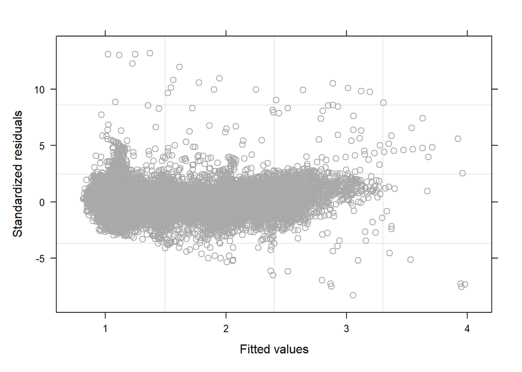

```r
plot(gls.6, col = "darkgrey")
```

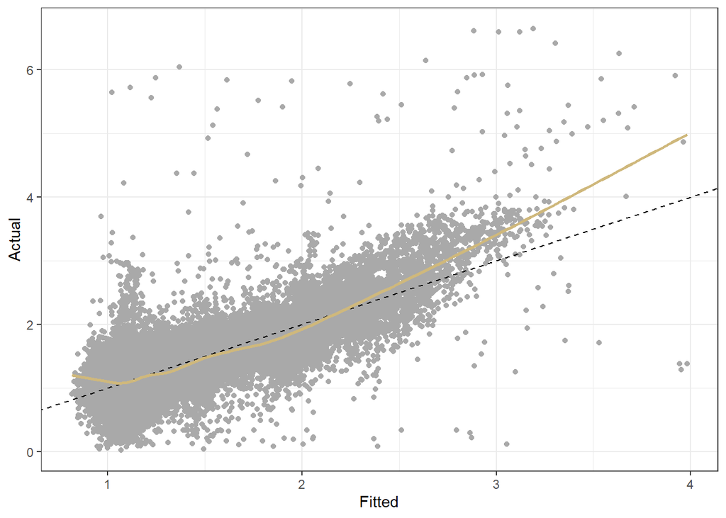

```r
ggplot(mapping = aes(x = fitted(gls.6), y = sqrt(df_ordered$CO))) + geom_point(col = "darkgrey")+
  geom_abline(slope = 1, intercept = 0, col = 'black',linetype = 'dashed')+
  geom_smooth(se = FALSE, col = "#CFB87C")+theme_bw()+xlab("Fitted") + ylab("Actual")
```

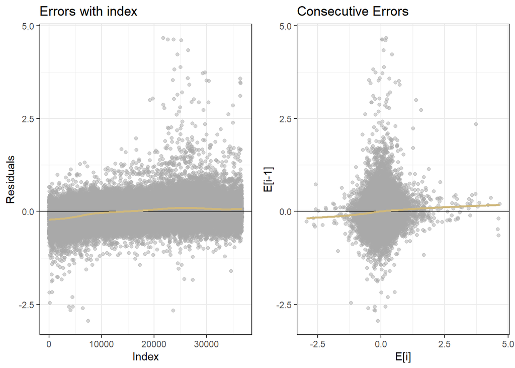

```r
ind <- order(df$CO)
p1 <- ggplot(mapping = aes(x = 1:length(df$CO), y = residuals(gls.6)[ind])) +
  geom_point(alpha = 0.5, col = 'darkgrey') +
  geom_abline(slope = 0, intercept = 0) +
  xlab("Index") +
  geom_smooth(se = F, col = "#CFB87C") +
  ylab("Residuals") +
  theme_bw()+ggtitle("Errors with index")

ordered.reiduals <- residuals(gls.6)[ind]
p2 <- ggplot(mapping = aes(x = ordered.reiduals[-length(ordered.reiduals)],
                           y = ordered.reiduals[-1]))+
               geom_point(alpha = 0.5, col = 'darkgrey') +
               geom_abline(slope = 0, intercept = 0) +
               xlab("E[i]") +
               geom_smooth(se = F, col = "#CFB87C") +
  ylab("E[i-1]") +
  theme_bw()+ggtitle("Consecutive Errors")

grid.arrange(p1,p2, nrow = 1)
```

```r
(cor.error <- cor(ordered.reiduals[-1],ordered.reiduals[-length(ordered.reiduals)]))
```

```
## [1] 0.07168549
```

** Checking MSPEs and MAE **

For all the models try to get MSPE and MAE by splitting it into train and test split

```r
set.seed(12)
n = floor(0.8 * nrow(df1))
index = sample(seq_len(nrow(df1)), size = n)

train = df1[index, ]
test = df1[-index, ]
head(train)
```

```
## # A tibble: 6 × 12
##      AT    AP    AH  AFDP  GTEP   TIT   TAT   TEY   CDP    CO   NOX  year
##   <dbl> <dbl> <dbl> <dbl> <dbl> <dbl> <dbl> <dbl> <dbl> <dbl> <dbl> <dbl>
## 1 29.8  1006.  52.5  3.30  21.1 1064.  550.  113.  11.0 1.16   53.0  2011
## 2 23.9  1012.  67.9  4.49  31.1 1100   536.  151.  13.5 0.331  55.3  2011
## 3 33.8  1009.  47.0  4.50  29.7 1100.  542.  145.  13.0 0.168  56.6  2011
## 4  5.10 1027.  80.5  5.48  33.6 1100.  523   168.  14.5 1.75   66.0  2011
## 5 26.9  1015.  55.9  3.03  20.0 1060.  550.  111.  10.6 3.04   58.8  2011
## 6  9.81 1018.  82.3  4.24  30.3 1100.  533.  159.  13.7 1.29   64.8  2011
```

```r
summary(train)
```

```
##        AT               AP             AH              AFDP
##  Min.   : 2.116   Min.   : 996   Min.   : 35.11   Min.   :2.779
##  1st Qu.:10.928   1st Qu.:1010   1st Qu.: 70.30   1st Qu.:3.657
##  Median :16.253   Median :1014   Median : 82.19   Median :4.031
##  Mean   :17.051   Mean   :1014   Mean   : 79.21   Mean   :4.096
##  3rd Qu.:23.347   3rd Qu.:1018   3rd Qu.: 89.84   3rd Qu.:4.480
##  Max.   :34.532   Max.   :1034   Max.   :100.17   Max.   :6.983
##       GTEP            TIT            TAT             TEY
##  Min.   :17.88   Min.   :1001   Min.   :512.6   Min.   :100.2
##  1st Qu.:23.42   1st Qu.:1083   1st Qu.:538.7   1st Qu.:132.1
##  Median :24.78   Median :1088   Median :549.9   Median :133.8
##  Mean   :25.68   Mean   :1085   Mean   :544.6   Mean   :135.9
##  3rd Qu.:29.83   3rd Qu.:1100   3rd Qu.:550.0   3rd Qu.:148.3
##  Max.   :35.97   Max.   :1101   Max.   :550.6   Max.   :170.0
##       CDP               CO                NOX              year
##  Min.   : 9.904   Min.   : 0.00039   Min.   : 43.27   Min.   :2011
##  1st Qu.:11.708   1st Qu.: 0.72435   1st Qu.: 60.38   1st Qu.:2011
##  Median :12.011   Median : 1.14715   Median : 65.63   Median :2011
##  Mean   :12.213   Mean   : 1.56313   Mean   : 67.70   Mean   :2011
##  3rd Qu.:13.247   3rd Qu.: 1.73620   3rd Qu.: 74.48   3rd Qu.:2011
##  Max.   :14.851   Max.   :43.62200   Max.   :119.32   Max.   :2011
```

```r
dim(train)
```

```
## [1] 5928   12
```

Model with the 6 predictors

```r
lm_mspe_6 <- lm(sqrt(CO) ~ AT + AH + GTEP + TIT + TAT + TEY, data = train)
summary(lm_mspe_6)
```

```
##
## Call:
## lm(formula = sqrt(CO) ~ AT + AH + GTEP + TIT + TAT + TEY, data = train)
##
## Residuals:
##     Min      1Q  Median      3Q     Max
## -2.8445 -0.1927  0.0001  0.1529  4.3777
##
## Coefficients:
##               Estimate Std. Error t value Pr(>|t|)
## (Intercept) 33.9806326  1.1223732  30.276  < 2e-16 ***
## AT          -0.0011012  0.0019247  -0.572  0.56724
## AH          -0.0011416  0.0003873  -2.948  0.00321 **
## GTEP        -0.2362127  0.0182271 -12.959  < 2e-16 ***
## TIT          0.0191119  0.0040211   4.753 2.05e-06 ***
## TAT         -0.0851056  0.0055280 -15.395  < 2e-16 ***
## TEY         -0.0077592  0.0049186  -1.578  0.11472
## ---
## Signif. codes:  0 '***' 0.001 '**' 0.01 '*' 0.05 '.' 0.1 ' ' 1
##
## Residual standard error: 0.3059 on 5921 degrees of freedom
## Multiple R-squared:  0.6393, Adjusted R-squared:  0.6389
## F-statistic:  1749 on 6 and 5921 DF,  p-value: < 2.2e-16
```

```r
sqrt_CO <- predict(lm_mspe_6, newdata = test[, c('AT', 'AH', 'GTEP', 'TIT', 'TAT', 'TEY')])
pred_CO <- sqrt_CO^2
length(pred_CO)
```

```
## [1] 1483
```

```r
mspe <- mean((pred_CO - test$CO)^2)
mspe
```

```
## [1] 1.495244
```

```r
mae <- mean(abs(pred_CO - test$CO))
mae
```

```
## [1] 0.5441176
```

Ridge Regression

```r
train_norm <- train %>% mutate(CO_sqrt = sqrt(CO))
train_norm <- train_norm %>% dplyr::select(-c(CO))

train_sd <- unlist(lapply(train_norm, sd))
#train_sd
train_mean <- unlist(lapply(train_norm, mean))
#train_mean

train_norm <-  as.data.frame(scale(train_norm))
#train_norm


test_norm <- test %>% mutate(CO_sqrt = sqrt(CO))
test_norm <- test_norm %>% dplyr::select(-c(CO))

test_norm <- sweep(sweep(as.matrix(test_norm), 2, t(as.matrix(train_mean))), 2, train_sd, FUN = '/')
test_norm <- as.data.frame(test_norm)
unlist(lapply(test_norm, mean))
```

```
##           AT           AP           AH         AFDP         GTEP          TIT
##  0.040835947  0.008091313 -0.013123308 -0.041740478 -0.015288682 -0.056096424
##          TAT          TEY          CDP          NOX         year      CO_sqrt
## -0.032796429 -0.034217319 -0.024302560 -0.057547562          NaN  0.043831971
```

```r
unlist(lapply(test_norm, sd))
```

```
##        AT        AP        AH      AFDP      GTEP       TIT       TAT       TEY
## 0.9666347 0.9979972 0.9967445 1.0436956 1.0477145 1.0521247 1.0351437 1.0524238
##       CDP       NOX      year   CO_sqrt
## 1.0509595 1.0266127        NA 0.9911436
```

```r
lm_ridge_l <- lm.ridge(CO_sqrt ~ AT + AP + AH + AFDP + GTEP + TIT + TAT + TEY + 0, data = train_norm, lambda = 3.8)
```

```r
y.pred <- as.matrix(test_norm %>% dplyr::select(c("AT","AP","AH","AFDP","GTEP","TIT","TAT","TEY"))) %*% coef(lm_ridge_l)
length(y.pred)
```

```
## [1] 1483
```

```r
y.pred_unnorm <- (y.pred*train_sd['CO_sqrt'] + train_mean['CO_sqrt'])^2
length(y.pred_unnorm)
```

```
## [1] 1483
```

```r
mspe <- mean((test$CO - y.pred_unnorm)^2)
mspe
```

```
## [1] 1.473822
```

```r
mae <- mean(abs(test$CO - y.pred_unnorm))
mae
```

```
## [1] 0.5360759
```

** GLS **

```r
library(nlme)
ind <- order(train$CO)
train_ordered <- train[ind,]
train_ordered$index <- 1:length(ind)
gls.6 <- gls(sqrt(CO) ~ AT + AH + GTEP + TIT + TAT + TEY - index, data = train_ordered, correlation = corAR1(form = ~ 1 | index))
summary(gls.6)
```

```
## Generalized least squares fit by REML
##   Model: sqrt(CO) ~ AT + AH + GTEP + TIT + TAT + TEY - index
##   Data: train_ordered
##        AIC      BIC    logLik
##   2870.277 2930.453 -1426.139
##
## Correlation Structure: AR(1)
##  Formula: ~1 | index
##  Parameter estimate(s):
## Phi
##   0
##
## Coefficients:
##                Value Std.Error    t-value p-value
## (Intercept) 33.98063 1.1223732  30.275698  0.0000
## AT          -0.00110 0.0019247  -0.572159  0.5672
## AH          -0.00114 0.0003873  -2.947904  0.0032
## GTEP        -0.23621 0.0182271 -12.959421  0.0000
## TIT          0.01911 0.0040211   4.752836  0.0000
## TAT         -0.08511 0.0055280 -15.395272  0.0000
## TEY         -0.00776 0.0049186  -1.577539  0.1147
##
##  Correlation:
##      (Intr) AT     AH     GTEP   TIT    TAT
## AT    0.691
## AH   -0.104  0.283
## GTEP -0.122 -0.652 -0.244
## TIT  -0.711 -0.233  0.231 -0.520
## TAT   0.476 -0.016 -0.264  0.718 -0.956
## TEY   0.874  0.833 -0.034 -0.292 -0.662  0.448
##
## Standardized residuals:
##           Min            Q1           Med            Q3           Max
## -9.2984714996 -0.6299915058  0.0001673513  0.4996839268 14.3102796246
##
## Residual standard error: 0.3059099
## Degrees of freedom: 5928 total; 5921 residual
```

```r
y.pred <- as.matrix(cbind(1,test %>% dplyr::select(c("AT","AH","GTEP","TIT","TAT","TEY")))) %*% gls.6$coefficients
y.pred <- y.pred^2
```

```r
mspe <- mean((test$CO - y.pred)^2)
mspe
```

```
## [1] 1.495244
```

```r
mae <- mean(abs(test$CO - y.pred))
mae
```

```
## [1] 0.5441176
```